# DSEM workshop

Jessica Schaaf and Michael Aristodemou

January 2024

Welcome to this tutorial on Dynamic Structural Equation Models (DSEMs; [Asparouhov et al., 2018](https://www.tandfonline.com/doi/full/10.1080/10705511.2017.1406803); [McNeish et al., 2020](https://oce.ovid.com/article/00060744-202010000-00005/HTML)) and how to fit them in Stan! This tutorial requires basic R skills. Some experience with timeseries modeling and/or Stan is helpful but not required. After completing this tutorial, you will be able to understand the basics of DSEM and Stan, to fit a DSEM with fixed and random effects in Stan, and hopefully to adjust the model to fit your own data.

Below you see six tabs. The first tab *Intro to DSEM* contains information on DSEMs and their parameters. The second tab *Get started* contains R code to load and format example data. The rest of the tabs contain step-by-step exercises to get used to fitting DSEMs in Stan.

## Content

### Intro to DSEM

This is a short introduction to DSEM, with pictures!

DSEM is used to analyze time series data. Time series data has multiple observations for a given subject on one or multiple variables. For example, if we measure John’s urge to smoke every day for 50 days we will get the kind of data we need. DSEM is also useful for when we have multiple observations for multiple subjects. Thus, it is instructive to think of DSEM as being composed of two models: (1) a within-subject model, describing a subject’s mean and variation around that mean that happens over time and (2) a between-subject model, capturing how these subject-specific characteristics differ between subjects. The number of parameters in a DSEM can vary depending on the substantive question you would like to answer. In this workshop we will go over the most popular DSEM which consists of three parameters. In the figure below you can see a visual representation of the three-parameter DSEM. We will break down each of these parameters below using our running example of smoking urges.

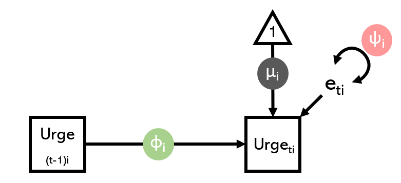

**1. Mean urge to smoke ($\mu$)**

The mean describes the average of a subject’s urge to smoke across all 50 days. This can be thought of as a stable point around which any variation happens. Subjects can differ in their mean value: as shown in the left panel of the figure below, the subject in blue has a higher mean urge to smoke. In the right panel, the model is described mathematically. We model a subject’s mean urge to smoke ($\mu_{i}$) as the sum of a group-level mean ($\gamma_{1}$) and a subject-specific deviation from that group-level mean ($\upsilon_{1i}$). In such a hierarchical framework, group-level effects are called fixed effects and the *sds* of subject-specific effects are called random effects. Note that you estimate sds of subject-specific effects, because estimating all separate effects is computationally expensive (read: impossible).

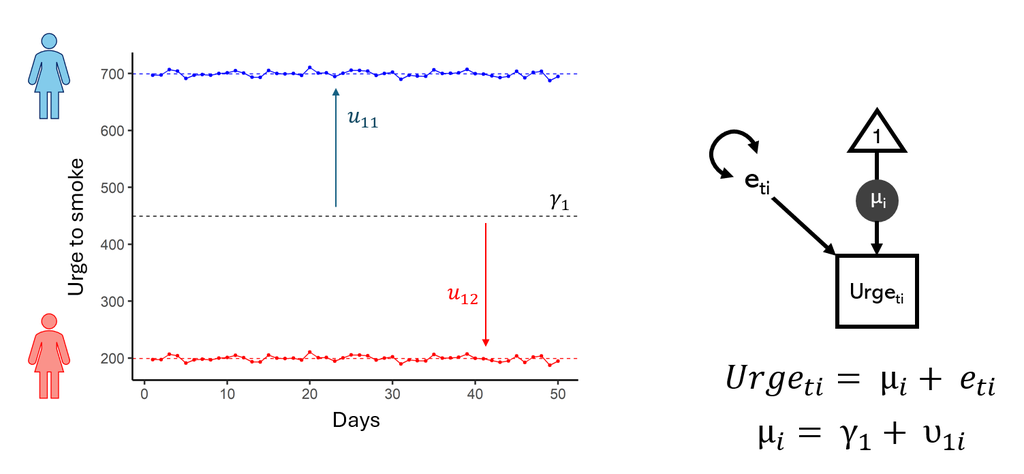

**2. Autoregression (AR-1; $\phi$)**

How much the urge to smoke on a given day differs from the mean urge across all 50 days is called a deviation. How much these deviations linger over time, that is, for how long subsequent urges will stay above or below the subject’s mean urge, is captured by the autoregressive parameter. For example, when a subject with a high positive autoregressive parameter (blue in left panel of the figure below) reports an urge to smoke that is higher than their mean urge, you can expect them to stay at that elevated level for longer than someone with a lower autoregressive parameter (red in left panel of figure). In the right panel, the statistical model again shows how a subject’s autoregressive parameter ($\phi_{i}$) is composed of a group-level autoregressive parameter ($\gamma_{2}$) and a subject-specific deviation ($\upsilon_{2i}$).

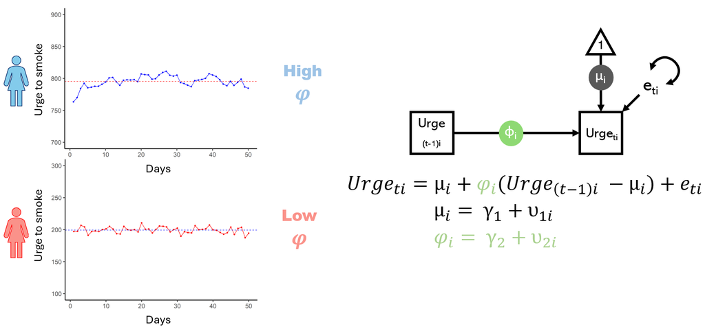

**3. Innovations ($\psi$)**

After taking into account the variation in urges that is explained by autoregression, our model still doesn’t fully capture all fluctuations. That is, we still have residual variation left. This residual variation is described by innovations. For example, two people who have the same level of urges on average and the same autoregression, may still differ in their day-to-day residual variation in their urges. In the left panel of the figure below, the two people shown are equal on all other parameters except their innovations (blue has greater residual sd). As can be seen in the right panel of the figure below, the general structure of the innovations is the same as for the mean and autoregression: a subject’s innovation ($\psi_{i}$) is composed of a group-level parameter ($\gamma_{3}$) and a subject-specific deviation ($\upsilon_{3i}$). You can ignore the exponential term for now, we explain it in the *N = 1 DSEM* module.

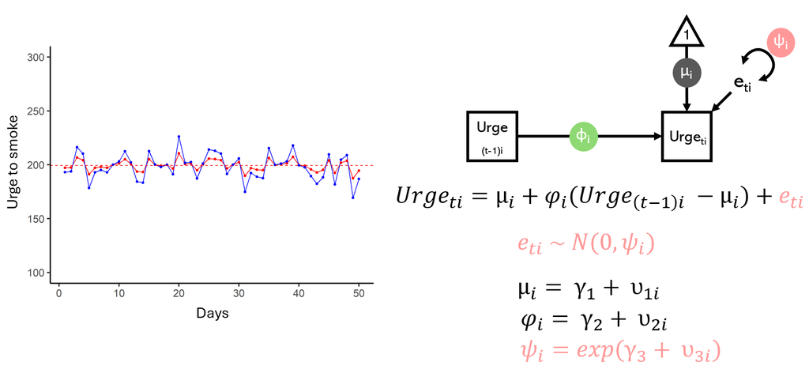

To continue to the next module and start fitting your first DSEM go back to the top.

### Get started

Before we start coding, let’s take care of some prerequisites. We need to access example data on smoking urges through GitHub and to restructure them a little to make them usable for Stan.

**Exercise 0: Run the following code to (1) rename columns, (2) subset data, and (3) turn data into a list for Stan.**

```r
#Load data
library(dplyr)

dat<-read.csv("https://raw.githubusercontent.com/mearistodemou/DSEM_workshop/main/Data/Two-Level%20Data.csv",header=F) #load McNeish data

#####################
# 1. Rename columns
####################

colnames(dat) <- c('urge',"dep",'js', "hs", 'subject', 'time') #rename columns

#####################
# 2. Subset data
####################

set.seed(5483)
# Get unique account_id
unique_id <- unique(dat$subject)

# 2.1 Subset N = 20
# Randomly select 20 participants
subsample <- sample(unique_id, size = 20)
dat_sub <- dat %>% filter(subject %in% subsample)

# 2.2 Subset data (N = 1)
dat_n1 <- dat_sub[which(dat_sub$subject == 5),]

###############################
# 3. Convert data into a list
##############################

# 3.1 Make list of variables and values for DSEM (N = 20)
dsem_list <- list(N_subj = length(unique(dat_sub$subject)), # subject number
                  Y = matrix(dat_sub$urge, 20, byrow = TRUE), # outcome variable matrix
                  N_obs = length(unique(dat_sub$time))) # number of observations


# 3.2 Make list of variables and values for DSEM (N = 1)
dsem_list_N1 <- list(Y = dat_n1$urge, # outcome variable matrix
                     N_obs = length(unique(dat_n1$time))) # number of observations
```

On to model fitting!

### N = 1 DSEM

We start with a simple version of a DSEM. That is, we estimate a DSEM for a single subject (N=1) with a mean and residual sd (no autoregression). As the data contain one subject, the model only includes fixed effects (no random ones). Mathematically, such a model is described as follows:

$$\begin{equation}
Y(t) = \mu + \epsilon(t)\label{eq1}\tag{1}
\end{equation}$$

where $Y$ indicates the subject’s smoking urges across trials $t$, $\mu$ (mu) is the mean urge, and $\epsilon$ (epsilon) is the residual, that is, the deviation of the observed urges from the mean urge. In the figure below, the red dotted line represents the mean and the distance between the observed data points (black) and that red line represent the deviations.

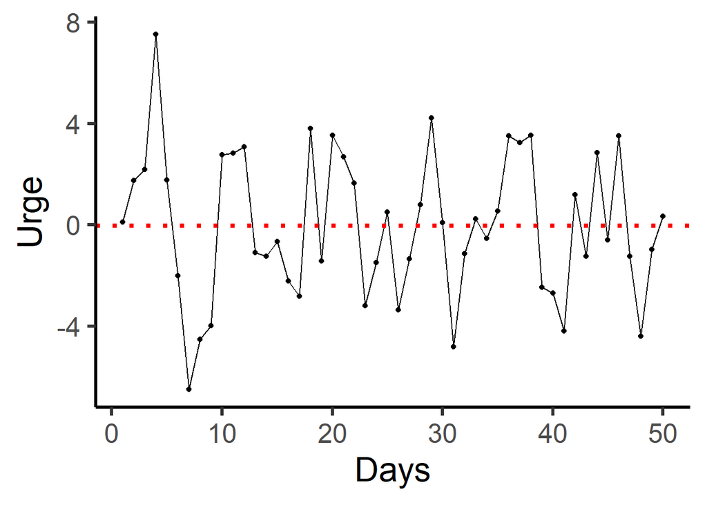

```r
#Plot timeseries data from McNeish data from one subject here with line for mean in plot
library(ggplot2)

#Basic time series (connected over all trials)
p3 <- ggplot(data = dat_n1, aes(x=time, y=urge)) +
  geom_point()+
  geom_line()
p3 <- p3 + geom_hline(yintercept=mean(dat_n1$urge), linewidth=1.5, linetype = 'dotted', col = 'red')
p3 <- p3 + labs(x="Days", y = "Urge")+
  theme_classic(base_size =  24)
p3
```

As it is computationally expensive (read: impossible) to estimate all separate deviations, you usually estimate the standard deviation of the deviations instead of the deviations themselves. We call this standard deviation a random effect and denote it with $\psi$ (psi).

**Stan in blocks**

Before we really get to model fitting, a small intermezzo on the workings of Stan. A Stan model is built up using [several blocks](https://mc-stan.org/docs/2_18/reference-manual/overview-of-stans-program-blocks.html). A simple model often requires a data block, a model block, and a parameters block.

1. In the *data block*, you specify which data to run the model on.
2. In the *model block*, you specify the model to fit on the data.
3. In the *parameters block*, you specify which parameters to sample in the model.

You may also add a *transformed parameters block* (in which you specify parameter transformations), a *generated quantities block* (in which you compute additional outputs such as posterior predictives), and a *functions block* (in which you specify potential functions used in any of the other blocks). Importantly, the model block runs locally. So if you want to use variables or parameters in the generated quantities block, you need to specify these in the transformed parameters block (instead of the model block). But that is for later; let’s go through the blocks one by one!

**The “model” block**

Let’s start by translating the model described above into Stan language. You do this in the model block. As a first step, you need to think about how the data are distributed. For simplicity, we assume data are distributed normally in this tutorial (however, your own data may be distributed differently). Stan uses the following notation for [normal distributions](https://mc-stan.org/docs/functions-reference/normal-distribution.html): data ~ normal(mean, sd). **Tip:** this page on [linear regression in Stan](https://mc-stan.org/docs/2_18/stan-users-guide/linear-regression.html) is a very helpful reference for the remainder of the workshop!

**Exercise 1**: Write a [for loop](https://mc-stan.org/docs/2_18/reference-manual/for-loops.html) across trials (call this variable *N_obs*) in which you translate the model described above into Stan language. **Tip:** Stan uses square brackets *[..]* for [indexing](https://mc-stan.org/docs/reference-manual/language-indexing.html) (just like R). Always end lines of code in Stan with a semi-colon (*;*).

```r
mymodel = "
  model {
    # Write your for loop and model here
  }
"
```

**Answer (Click “Show” if you need some help)**

```r
mymodel = "
  model {
    for (t in 1:N_obs) {
      Y[t] ~ normal(mu, psi);   # basic DSEM
    }
  }
"
```

Congratulations! You have created the basis of a DSEM. In the remainder, we make sure Stan knows what to do with it :)

In Stan, you need to specify [the type of data and variables](https://mc-stan.org/docs/2_18/reference-manual/univariate-data-types-and-variable-declarations.html) you include.

**Exercise 2a**: Extend the model block from Exercise 1 by specifying that mu and psi are unconstrained real numbers. Don’t forget to end each line with a semi-colon!

```r
mymodel = "
  model {
    # Add declarations here

    for (t in 1:N_obs) {
      Y[t] ~ normal(mu, psi);   # basic DSEM
    }
  }
"
```

**Answer (Click “Show” if you need some help)**

```r
mymodel = "
  model {
    real mu;                    # mean
    real psi;                   # residual sd

    for (t in 1:N_obs) {
      Y[t] ~ normal(mu, psi);   # basic DSEM
    }
  }
"
```

In our simple model, we only model data for one subject This means that the subject-specific parameters (mean $\mu$ and residual sd $\psi$) are equal to the fixed effects. That is, $\mu = \gamma_1$ and $\psi = \gamma_2$.

**Exercise 2b**: Extend the model from Exercise 2b with lines of code in which you specify that the mean and residual sd are equal to the fixed effects. **Tip**: Use indexing to create two gammas.

```r
mymodel = "
  model {
    real mu;                    # mean
    real psi;                   # residual

    # Add declarations here

    for (t in 1:N_obs) {
      Y[t] ~ normal(mu, psi);   # basic DSEM
    }

  }
"
```

**Answer (Click “Show” if you need some help)**

```r
mymodel = "
  model {
    real mu;                    # mean
    real psi;                   # residual sd

    mu = gamma[1];              # subject-specific mean equals fixed effect
    psi = gamma[2];             # subject-specific sd equals fixed effect

    for (t in 1:N_obs) {
      Y[t] ~ normal(mu, psi);   # basic DSEM
    }

  }
"
```

You have now declared mu and psi. However, there are still variables (N_obs and Y) and parameters (gamma[1] and gamma[2]) that Stan doesn’t understand. We start by declaring the parameters. This is done in the parameters block.

**The “parameters” block**

**Exercise 3**: Let’s create a new block, a parameters block. In this block, declare that you have a [vector](https://mc-stan.org/docs/2_18/reference-manual/vector-and-matrix-data-types.html) of two parameters called gamma.

```r
mymodel = "
  parameters {
    # Add declarations here
  }

  model {
    real mu;                    # mean
    real psi;                   # residual sd

    mu = gamma[1];              # subject-specific mean equals fixed effect
    psi = gamma[2];             # subject-specific sd equals fixed effect

    for (t in 1:N_obs) {
      Y[t] ~ normal(mu, psi);   # basic DSEM
    }

  }"
```

**Answer (Click “Show” if you need some help)**

```r
mymodel = "
  parameters {
    vector[2] gamma;            # fixed effects
  }

  model {
    real mu;                    # mean
    real psi;                   # residual sd

    mu = gamma[1];              # subject-specific mean equals fixed effect
    psi = gamma[2];             # subject-specific sd equals fixed effect

    for (t in 1:N_obs) {
      Y[t] ~ normal(mu, psi);   # basic DSEM
    }

  }
"
```

Good job! You’re almost there. You still need to give Stan the number of observations and the timeseries data (outcome variable). You do this in another block, the data block.

**The “data” block**

**Exercise 4**: Create a data block in which you specify the number of observations and the timeseries data (outcome variable). First think about the [variable type](https://mc-stan.org/docs/2_18/reference-manual/univariate-data-types-and-variable-declarations.html), whether or not the variables are constrained (i.e., does the number of observations have a lower or upper bound?), and the size of the variables.

```r
mymodel = "
  # Add data block here

  parameters {
    vector[2] gamma;            # fixed effects
  }

  model {
    real mu;                    # mean
    real psi;                   # residual sd

    mu = gamma[1];              # subject-specific mean equals fixed effect
    psi = gamma[2];             # subject-specific sd equals fixed effect

    for (t in 1:N_obs) {
      Y[t] ~ normal(mu, psi);   # basic DSEM
    }

  }
"
```

**Answer (Click “Show” if you need some help)**

```r
mymodel = "
  data {
    int<lower=1> N_obs;         # number of observations
    vector[N_obs] Y;            # timeseries data
  }

  parameters {
    vector[2] gamma;            # fixed effects
  }

  model {
    real mu;                    # mean
    real psi;                   # residual sd

    mu = gamma[1];              # subject-specific mean equals fixed effect
    psi = gamma[2];             # subject-specific sd equals fixed effect

    for (t in 1:N_obs) {
      Y[t] ~ normal(mu, psi);   # basic DSEM
    }

  }
"
```

Stan uses Bayesian parameter estimation. It is beyond the scope of this tutorial to explain what Bayesian estimation is. If you want to know more about Bayesian statistics and -estimation you could read [this paper](https://www.ejwagenmakers.com/2015/BayesianAnalysisEnclopedia.pdf).

To perform Bayesian estimation, we need to define prior distributions for the parameters. In this simple model, we included two parameters. Which ones?

**Exercise 5a**: In the model block, specify a prior distribution for the fixed effects ($\gamma$s). Try to implement a normal distribution with a mean of zero and a large standard deviation (e.g., 1e6). Remember from Exercise 1 that such a specification follows the form data ~ normal(mean, sd). **Tip**: Stan uses [vectorization](https://mc-stan.org/docs/2_18/stan-users-guide/vectorization.html) so you don’t need to specify the prior for the two fixed effects separately.

```r
mymodel = "
  data {
    int<lower=1> N_obs;         # number of observations
    vector[N_obs] Y;            # timeseries data
  }

  parameters {
    vector[2] gamma;            # fixed effects
  }

  model {
    real mu;                    # mean
    real psi;                   # residual sd

    mu = gamma[1];              # subject-specific mean equals fixed effect
    psi = gamma[2];             # subject-specific sd equals fixed effect

    # Add prior here

    for (t in 1:N_obs) {
      Y[t] ~ normal(mu, psi);   # basic DSEM
    }

  }
"
```

**Answer (Click “Show” if you need some help)**

```r
mymodel = "
  data {
    int<lower=1> N_obs;         # number of observations
    vector[N_obs] Y;            # timeseries data
  }

  parameters {
    vector[2] gamma;            # fixed effects
  }

  model {
    real mu;                    # mean
    real psi;                   # residual sd

    mu = gamma[1];              # subject-specific mean equals fixed effect
    psi = gamma[2];             # subject-specific sd equals fixed effect

    gamma ~ normal(0, 1e6);     # prior on fixed effects (1e6 is shorthand for 1000000)

    for (t in 1:N_obs) {
      Y[t] ~ normal(mu, psi);   # basic DSEM
    }

  }
"
```

Is it likely that both fixed effects follow a normal distribution? Not really… sds such as the residual sd (psi) cannot be negative and are often skewed. What is usually done in DSEM is log-transforming the residual sd to approximate a normal distribution.

**Exercise 5b**: Modify the declaration of psi (i.e., “psi = gamma[2];”) to make sure $\gamma_2$ is estimated on a logarithmic scale.

**Answer (Click “Show” if you need some help)**

```r
mymodel = "
  data {
    int<lower=1> N_obs;         # number of observations
    vector[N_obs] Y;            # timeseries data
  }

  parameters {
    vector[2] gamma;            # fixed effects
  }

  model {
    real mu;                    # mean
    real psi;                   # residual sd

    mu = gamma[1];              # subject-specific mean equals fixed effect
    psi = exp(gamma[2]);        # subject-specific sd equals fixed effect

    gamma ~ normal(0, 1e6);     # prior on fixed effects

    for (t in 1:N_obs) {
      Y[t] ~ normal(mu, psi);   # basic DSEM
    }

  }
"
```

DONE! Now you can run the model on data from the McNeish paper.

**Fitting your model**

```r
# R code for fitting the model here
library(rstan)

mod <- stan(model_code = mymodel, data = dsem_list_N1,
            verbose = FALSE, iter = 1000, chains = 4,
            cores = 4, init = 0)
```

```r
# R code for quick inspection of results here
print(mod, digits = 3, pars = c('gamma'))
```

```
## Inference for Stan model: anon_model.
## 4 chains, each with iter=1000; warmup=500; thin=1;
## post-warmup draws per chain=500, total post-warmup draws=2000.
##
##            mean se_mean    sd   2.5%    25%    50%   75% 97.5% n_eff  Rhat
## gamma[1] -0.036   0.010 0.418 -0.864 -0.314 -0.038 0.245 0.781  1726 1.000
## gamma[2]  1.073   0.003 0.102  0.877  1.003  1.070 1.137 1.282  1541 0.999
##
## Samples were drawn using NUTS(diag_e) at Wed Jan 24 20:55:32 2024.
## For each parameter, n_eff is a crude measure of effective sample size,
## and Rhat is the potential scale reduction factor on split chains (at
## convergence, Rhat=1).
```

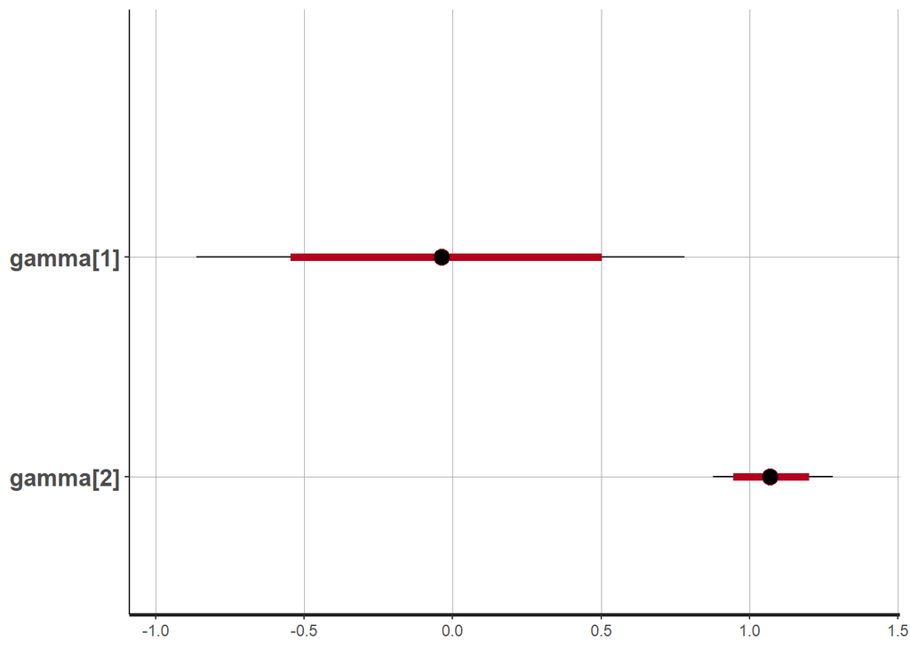

```r
plot(mod, pars = c('gamma'))
```

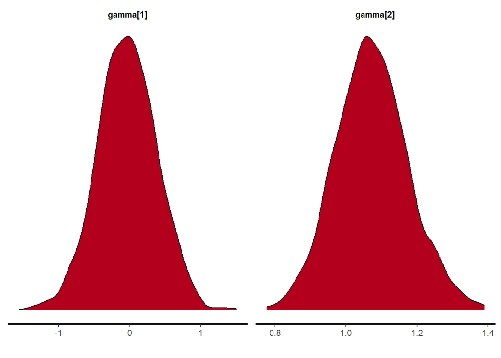

```r
stan_dens(mod, pars = c('gamma'))
```

If everything ran correctly, the mean urge to smoke (gamma[1]) is estimated around zero and the log-transformed residual sd (gamma[2]) is estimated slightly above one. To ease interpretation, you could exponentiate the log-transformed residual sd, which will give you an sd of about three. These results, a mean of zero and a standard deviation of three, make sense if you look back at the figure at the top of this module.

Let’s make it a little more difficult in the next module!

### Adding autoregression

The DSEM in the previous section is incomplete. Specifically, it doesn’t include a term for the (first-order) autoregression. The autoregression indicates how the deviation at the previous timepoint correlates with the score on the current timepoint. With a little algebra, we can rework Equation $\eqref{eq1}$ (see *N = 1 DSEM* module) to obtain the deviation on the current timepoint:
$$\begin{equation}
\epsilon_{t} = Y_{t} - \mu\label{eq2}\tag{2}
\end{equation}$$
From this follows that the deviation on the previous timepoint is:

$$\begin{equation}
\epsilon_{t-1} = Y_{t-1} - \mu\label{eq3}\tag{3}
\end{equation}$$

A model including autoregression, which we coin $\phi$, can thus be described as:
$$\begin{align}
Y_{t} &= \mu + \phi \cdot \epsilon_{t-1} + \epsilon_{t} \\
&= \mu + \phi \cdot (Y_{t-1} - \mu) + \epsilon_{t}\label{eq4}\tag{4}
\end{align}$$
**Hint:** Before continuing with the exercises, think about which parts of the code you need to adjust to now model the timeseries data using three instead of two parameters.

**Exercise 6**: One of the things you need to do is augment the basic DSEM you created in Exercise 1 with an autoregression. Try to implement Equation $\eqref{eq4}$ in the model block of your Stan model.

**Answer (Click “Show” if you need some help)**

```r
mymodel = "
  data {
    int<lower=1> N_obs;         # number of observations
    vector[N_obs] Y;            # timeseries data
  }

  parameters {
    vector[2] gamma;            # fixed effects
  }

  model {
    real mu;                    # mean
    real psi;                   # residual sd

    mu = gamma[1];              # subject-specific mean equals fixed effect
    psi = exp(gamma[2]);        # subject-specific sd equals fixed effect

    gamma ~ normal(0, 1e6);     # prior on fixed effects

    for (t in 1:N_obs) {
      Y[t] ~ normal(mu + phi*(Y[t-1] - mu), psi);   # three-parameter DSEM
    }

  }
"
```

**Exercise 7**: You also need to (1) tell Stan that you now have three instead of two fixed effects (in the parameters block; see Exercise 3), (2) declare the new parameter (in the model block; see Exercise 2a), and (3) specify that the subject-specific autoregression is equal to the fixed effect (see Exercise 2b). Try to change these in your Stan code.

**Answer (Click “Show” if you need some help)**

```r
mymodel = "
  data {
    int<lower=1> N_obs;         # number of observations
    vector[N_obs] Y;            # timeseries data
  }

  parameters {
    vector[3] gamma;            # fixed effects
  }

  model {
    real mu;                    # mean
    real psi;                   # residual sd
    real phi;                   # autoregression

    mu = gamma[1];              # subject-specific mean equals fixed effect
    psi = exp(gamma[2]);        # subject-specific sd equals fixed effect
    phi = gamma[3];             # subject-specific autoregression equals fixed effect

    gamma ~ normal(0, 1e6);     # prior on fixed effects

    for (t in 1:N_obs) {
      Y[t] ~ normal(mu + phi*(Y[t-1] - mu), psi);   # three-parameter DSEM
    }

  }
"
```

Now run your model and inspect the results!

```r
# R code for fitting the model here
library(rstan)

mod <- stan(model_code = mymodel, data = dsem_list_N1,
            verbose = FALSE, iter = 1000, chains = 4,
            cores = 4, init = 0)

# View results
print(mod, digits = 3, pars = c('gamma'))
```

```
## Inference for Stan model: anon_model.
## 4 chains, each with iter=1000; warmup=500; thin=1;
## post-warmup draws per chain=500, total post-warmup draws=2000.
##
##            mean se_mean    sd   2.5%    25%    50%   75% 97.5% n_eff  Rhat
## gamma[1] -0.033   0.016 0.666 -1.392 -0.452 -0.030 0.374 1.284  1656 1.003
## gamma[2]  1.030   0.003 0.101  0.837  0.961  1.028 1.102 1.224  1590 0.999
## gamma[3]  0.344   0.004 0.141  0.065  0.248  0.341 0.437 0.624  1498 1.001
##
## Samples were drawn using NUTS(diag_e) at Wed Jan 24 20:56:12 2024.
## For each parameter, n_eff is a crude measure of effective sample size,
## and Rhat is the potential scale reduction factor on split chains (at
## convergence, Rhat=1).
```

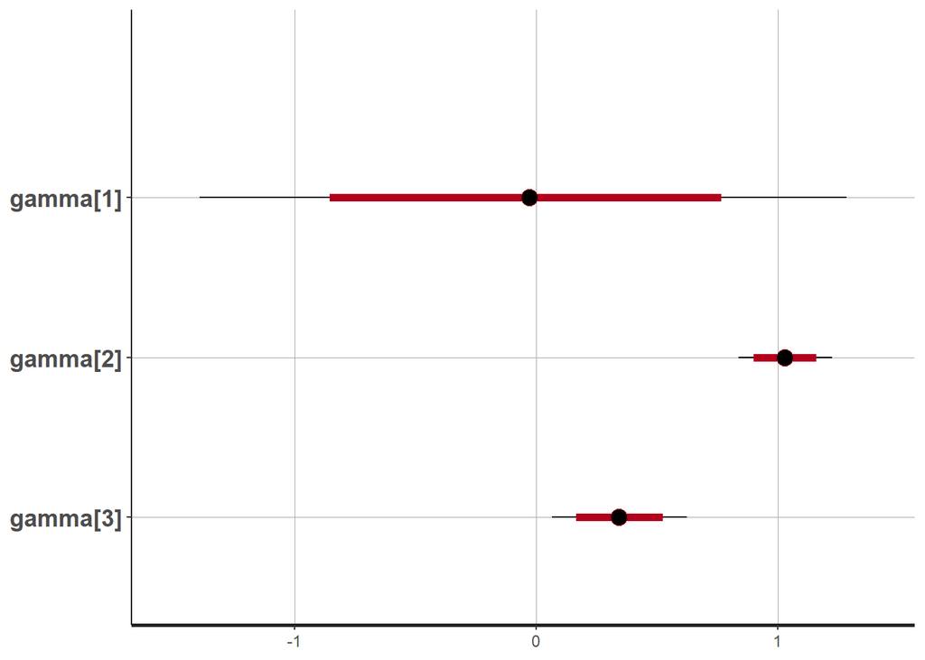

```r
plot(mod, pars = c('gamma'))
```

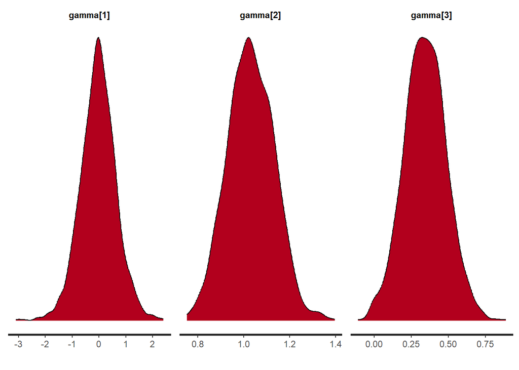

```r
stan_dens(mod, pars = c('gamma'))
```

As you can see, an additional parameter (gamma[3]) is estimated. This autoregressive parameter is estimated around 0.35, suggesting the subject’s smoking urge carries over across days. In other words, if the subject experiences elevated urges today, they are more likely to experience elevated urges again tomorrow.

Let’s go on to find out how we can extend our model to examine how urges to smoke fluctuate across days in a given population. Next module.

### N > 1 DSEM

Now that we have a three-parameter DSEM, it would be nice to be able to fit the model on multiple subjects. First think about which parts of the model you need to adjust to allow it to estimate parameters for multiple subjects at once.

**Exercise 8**: Let’s start from the top. In the data block, we need to tell Stan how many subjects we have. Call this variable *N_subj*. **Tip**: Look back at Exercise 4. We also need to declare [a new structure](https://mc-stan.org/docs/reference-manual/overview-of-data-types.html) for our timeseries data as we now have multiple observations for multiple subjects.

**Answer (Click “Show” if you need some help)**

```r
mymodel1 = "
  data {
    int<lower=1> N_obs;         # number of observations
    int<lower=1> N_subj;        # number of subjects
    array[N_subj] vector[N_obs] Y;  # timeseries data
  }

  parameters {
    vector[3] gamma;            # fixed effects
  }

  model {
    real mu;                    # mean
    real psi;                   # residual sd
    real phi;                   # autoregression

    mu = gamma[1];              # subject-specific mean equals fixed effect
    psi = exp(gamma[2]);        # subject-specific sd equals fixed effect
    phi = gamma[3];             # subject-specific autoregression equals fixed effect

    gamma ~ normal(0, 1e6);     # prior on fixed effects

    for (t in 1:N_obs) {
      Y[t] ~ normal(mu + phi*(Y[t-1] - mu), psi);   # three-parameter DSEM
    }

  }
"
```

**Exercise 9**: In the model block, you also need to specify another structure for the subject-specific parameters as we now have N_subj $\mu$s, $\psi$s and $\phi$s. Can you implement that?

**Answer (Click “Show” if you need some help)**

```r
mymodel1 = "
  data {
    int<lower=1> N_obs;         # number of observations
    int<lower=1> N_subj;        # number of subjects
    array[N_subj] vector[N_obs] Y;  # timeseries data
  }

  parameters {
    vector[3] gamma;            # fixed effects
  }

  model {
    vector[N_subj] mu;          # mean
    vector[N_subj] psi;         # residual sd
    vector[N_subj] phi;         # autoregression

    mu = gamma[1];              # subject-specific mean equals fixed effect
    psi = exp(gamma[2]);        # subject-specific sd equals fixed effect
    phi = gamma[3];             # subject-specific autoregression equals fixed effect

    gamma ~ normal(0, 1e6);     # prior on fixed effects

    for (t in 1:N_obs) {
        Y[t] ~ normal(mu + phi*(Y[t-1] - mu), psi);   # three-parameter DSEM
      }
  }
"
```

**Exercise 10**: Finally, in the model block, you need to add a for loop across subjects and subject indices within that loop. Which parts of the model are per subject? Try to implement it! **Tip**: Indexing in Stan can be done in “the R way”, that is, x[a,b], but is usually done differently: x[a][b].

**Answer (Click “Show” if you need some help)**

```r
mymodel1 = "
  data {
    int<lower=1> N_obs;         # number of observations
    int<lower=1> N_subj;        # number of subjects
    array[N_subj] vector[N_obs] Y;  # timeseries data
  }

  parameters {
    vector[3] gamma;            # fixed effects
  }

  model {
    vector[N_subj] mu;          # mean
    vector[N_subj] psi;         # residual sd
    vector[N_subj] phi;         # autoregression

    gamma ~ normal(0, 1e6);     # prior on fixed effects

    for (i in 1:N_subj) {
      mu[i] = gamma[1];              # subject-specific mean equals fixed effect
      psi[i] = exp(gamma[2]);        # subject-specific sd equals fixed effect
      phi[i] = gamma[3];             # subject-specific autoregression equals fixed effect

      for (t in 1:N_obs) {
        Y[i][t] ~ normal(mu[i] + phi[i]*(Y[i][t-1] - mu[i]), psi[i]);   # three-parameter DSEM
      }

    }
  }
"
```

Great! You can now fit the model and get parameter estimates for every subject. Note that we are using a different dataset (with 20 subjects instead of 1) the list that we feed into Stan is also different. Take a moment to notice the changes.

```r
library(rstan)

#Make list of variables and values for DSEM (N = 20)
dsem_list <- list(N_subj = length(unique(dat_sub$subject)), # subject number
                  Y = matrix(dat_sub$urge, 20, byrow = TRUE), # outcome variable matrix
                  N_obs = length(unique(dat_sub$time))) # number of observations

# R code for fitting the model here
mod <- stan(model_code = mymodel1, data = dsem_list,
            verbose = FALSE, iter = 500, chains = 4,
            cores = 4, init = 0)

# View results
print(mod, digits = 3, pars = c('gamma'))
```

```
## Inference for Stan model: anon_model.
## 4 chains, each with iter=500; warmup=250; thin=1;
## post-warmup draws per chain=250, total post-warmup draws=1000.
##
##            mean se_mean    sd   2.5%    25%    50%    75% 97.5% n_eff  Rhat
## gamma[1] -0.092   0.003 0.074 -0.235 -0.144 -0.094 -0.043 0.059   835 0.998
## gamma[2]  0.452   0.001 0.022  0.409  0.438  0.452  0.466 0.495   645 0.997
## gamma[3]  0.332   0.001 0.030  0.273  0.312  0.333  0.353 0.388   923 1.000
##
## Samples were drawn using NUTS(diag_e) at Wed Jan 24 20:56:53 2024.
## For each parameter, n_eff is a crude measure of effective sample size,
## and Rhat is the potential scale reduction factor on split chains (at
## convergence, Rhat=1).
```

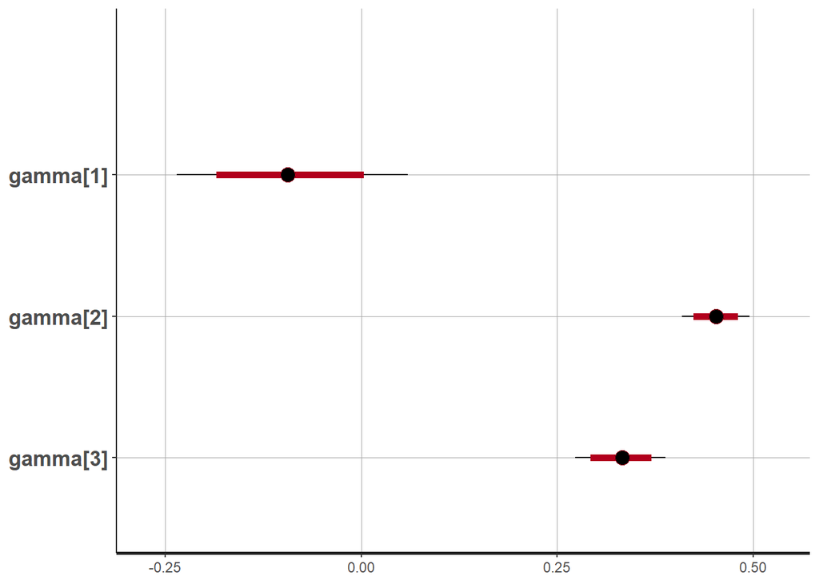

```r
plot(mod, pars = c('gamma'))
```

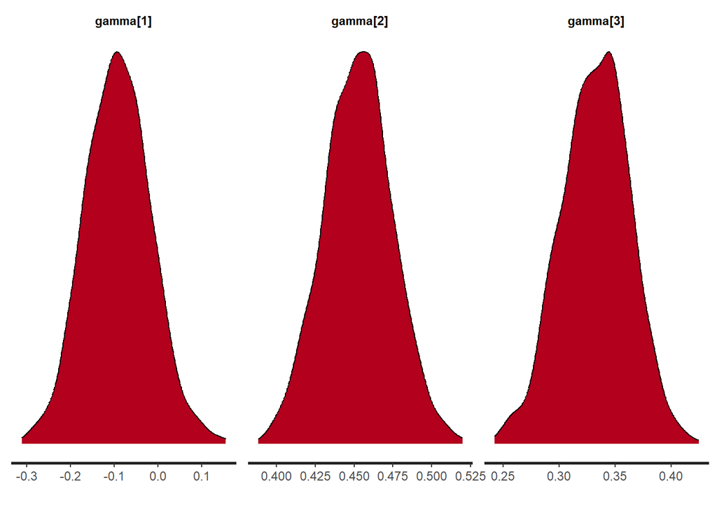

```r
stan_dens(mod, pars = c('gamma'))
```

You’ve come a long way! You are now able to describe the average urges to smoke in our sample, how much deviations in people’s urges linger on average, and how much residual fluctuation there is in people’s urges. But not everyone’s urge to smoke is represented by these sample averages. How can we account for these individual differences? We will find out in the final section.

### Multilevel DSEM

It is time to go hierarchical! In the previous module, you fitted a three-parameter DSEM to data from multiple subjects. However, you didn’t allow subjects to differ in their parameters yet. That is, we modeled subject-specific parameters as fixed effects without estimating random effects. We now want to allow subjects to differ from each other. For this, we need to specify subject-specific deviations and estimate random effects.

**Exercise 11**: In our previous models, we specified that subject-specific effects are equal to the fixed effects. Add subject-specific deviations to the definition of subject-specific effects. Call these deviations u. Remember that you can use indexing to create multiple u’s at once.

```r
mymodel2 = "
  data {
    int<lower=1> N_obs;         # number of observations
    int<lower=1> N_subj;        # number of subjects
    array[N_subj] vector[N_obs] Y;  # timeseries data
  }

  parameters {
    vector[3] gamma;        # fixed effects
  }

  model {
    vector[N_subj] mu;          # mean
    vector[N_subj] psi;         # residual sd
    vector[N_subj] phi;         # autoregression

    gamma ~ normal(0, 1e6);     # prior on fixed effects


    for (i in 1:N_subj) {
      mu[i] = gamma[1] + u[i][1];              # subject-specific mean
      psi[i] = exp(gamma[2] + u[i][2]);        # subject-specific sd
      phi[i] = gamma[3] + u[i][3];             # subject-specific autoregression

      for (t in 1:N_obs) {
        Y[i][t] ~ normal(mu[i] + phi[i]*(Y[i][t-1] - mu[i]), psi[i]); # three-parameter DSEM
      }
    }
  }
"
```

**Exercise 12**: In the parameters block, declare the deviations added in Exercise 11. What structure do these deviations have? And what size? And what type of variable are we dealing with?

```r
mymodel2 = "
  data {
    int<lower=1> N_obs;         # number of observations
    int<lower=1> N_subj;        # number of subjects
    array[N_subj] vector[N_obs] Y;  # timeseries data
  }

  parameters {
    vector[3] gamma;        # fixed effects
    array[N_subj] vector[3] u; #deviations
  }

  model {
    vector[N_subj] mu;          # mean
    vector[N_subj] psi;         # residual sd
    vector[N_subj] phi;         # autoregression

    gamma ~ normal(0, 1e6);     # prior on fixed effects

    for (i in 1:N_subj) {
      mu[i] = gamma[1] + u[i][1];              # subject-specific mean
      psi[i] = exp(gamma[2] + u[i][2]);        # subject-specific sd
      phi[i] = gamma[3] + u[i][3];             # subject-specific autoregression

      for (t in 1:N_obs) {
        Y[i][t] ~ normal(mu[i] + phi[i]*(Y[i][t-1] - mu[i]), psi[i]); # three-parameter DSEM
      }
    }
  }
"
```

**Exercise 13**: Now that we added deviations to the model (Exercise 11) and declared them (Exercise 12), we need to specify a prior on the deviations. As with the prior on the fixed effects (Exercise 5a), you do this in the model block. We assume deviations are normally distributed with a mean of zero and an sd that we make a parameter. Call this parameter tau. This exercise is very similar to defining the prior on the fixed effects; apart from introducing the parameter tau, what is different?

```r
mymodel2 = "
  data {
    int<lower=1> N_obs;         # number of observations
    int<lower=1> N_subj;        # number of subjects
    array[N_subj] vector[N_obs] Y;  # timeseries data
  }

  parameters {
    vector[3] gamma;        # fixed effects
    array[N_subj] vector[3] u; #deviations
  }

  model {
    vector[N_subj] mu;          # mean
    vector[N_subj] psi;         # residual sd
    vector[N_subj] phi;         # autoregression

    gamma ~ normal(0, 1e6);     # prior on fixed effects

    for (i in 1:N_subj) {
      u[i] ~ normal(0, tau);    # distribution of deviations

      mu[i] = gamma[1] + u[i][1];              # subject-specific mean
      psi[i] = exp(gamma[2] + u[i][2]);        # subject-specific sd
      phi[i] = gamma[3] + u[i][3];             # subject-specific autoregression

      for (t in 1:N_obs) {
        Y[i][t] ~ normal(mu[i] + phi[i]*(Y[i][t-1] - mu[i]), psi[i]); # three-parameter DSEM
      }
    }
  }
"
```

**Exercise 14**: In the previous exercise, we introduced a new parameter *tau*. Declare this parameter in the parameters block. What is the type? And the size? Does it have a lower or upper bound?

```r
mymodel2 = "
  data {
    int<lower=1> N_obs;         # number of observations
    int<lower=1> N_subj;        # number of subjects
    array[N_subj] vector[N_obs] Y;  # timeseries data
  }

  parameters {
    vector[3] gamma;        # fixed effects
    vector<lower=0>[3] tau; # random effects
    array[N_subj] vector[3] u; #deviations
  }

  model {
    vector[N_subj] mu;          # mean
    vector[N_subj] psi;         # residual sd
    vector[N_subj] phi;         # autoregression

    gamma ~ normal(0, 1e6);     # prior on fixed effects

    for (i in 1:N_subj) {
      u[i] ~ normal(0, tau);    # distribution of deviations

      mu[i] = gamma[1] + u[i][1];              # subject-specific mean
      psi[i] = exp(gamma[2] + u[i][2]);        # subject-specific sd
      phi[i] = gamma[3] + u[i][3];             # subject-specific autoregression

      for (t in 1:N_obs) {
        Y[i][t] ~ normal(mu[i] + phi[i]*(Y[i][t-1] - mu[i]), psi[i]); # three-parameter DSEM
      }
    }
  }
"
```

**Exercise 15**: We also need to add a prior on this newly introduced parameter in the model block. As tau is a standard deviation, which cannot be negative, we use a [cauchy prior distribution](https://mc-stan.org/docs/functions-reference/cauchy-distribution.html). Set the location parameter (i.e., the first argument) to zero and the scale (i.e., the second argument) to 2.5.

```r
mymodel2 = "
  data {
    int<lower=1> N_obs;         # number of observations
    int<lower=1> N_subj;        # number of subjects
    array[N_subj] vector[N_obs] Y;  # timeseries data
  }

  parameters {
    vector[3] gamma;        # fixed effects
    vector<lower=0>[3] tau; # random effects
    array[N_subj] vector[3] u; #deviations
  }

  model {
    vector[N_subj] mu;          # mean
    vector[N_subj] psi;         # residual sd
    vector[N_subj] phi;         # autoregression

    gamma ~ normal(0, 1e6);     # prior on fixed effects
    tau ~ cauchy(0,2.5);        # prior on random effects

    for (i in 1:N_subj) {
      u[i] ~ normal(0, tau);    # distribution of deviations

      mu[i] = gamma[1] + u[i][1];              # subject-specific mean
      psi[i] = exp(gamma[2] + u[i][2]);        # subject-specific sd
      phi[i] = gamma[3] + u[i][3];             # subject-specific autoregression

      for (t in 1:N_obs) {
        Y[i][t] ~ normal(mu[i] + phi[i]*(Y[i][t-1] - mu[i]), psi[i]); # three-parameter DSEM
      }
    }
  }
"
```

Now you can run the three-parameter DSEM model with random effects!

```r
library(rstan)

#Make list of variables and values for DSEM (N = 20)
dsem_list <- list(N_subj = length(unique(dat_sub$subject)), # subject number
                  Y = matrix(dat_sub$urge, 20, byrow = TRUE), # outcome variable matrix
                  N_obs = length(unique(dat_sub$time))) # number of observations

# R code for fitting the model here
mod <- stan(model_code = mymodel2, data = dsem_list,
            verbose = FALSE, iter = 4000, chains = 4,
            cores = 4, init = 0)

# View results
print(mod, digits = 3, pars = c('gamma','tau'))
```

```
## Inference for Stan model: anon_model.
## 4 chains, each with iter=4000; warmup=2000; thin=1;
## post-warmup draws per chain=2000, total post-warmup draws=8000.
##
##            mean se_mean    sd   2.5%    25%    50%   75% 97.5% n_eff  Rhat
## gamma[1] -0.091   0.007 0.208 -0.507 -0.225 -0.086 0.041 0.310   871 1.013
## gamma[2]  0.241   0.003 0.088  0.065  0.184  0.241 0.299 0.405   715 1.005
## gamma[3]  0.112   0.001 0.036  0.042  0.088  0.112 0.136 0.183  3027 1.001
## tau[1]    0.874   0.003 0.161  0.620  0.759  0.852 0.970 1.247  4067 1.001
## tau[2]    0.379   0.001 0.072  0.266  0.327  0.372 0.418 0.548  5142 1.000
## tau[3]    0.053   0.002 0.038  0.006  0.023  0.045 0.077 0.145   237 1.023
##
## Samples were drawn using NUTS(diag_e) at Wed Jan 24 20:58:01 2024.
## For each parameter, n_eff is a crude measure of effective sample size,
## and Rhat is the potential scale reduction factor on split chains (at
## convergence, Rhat=1).
```

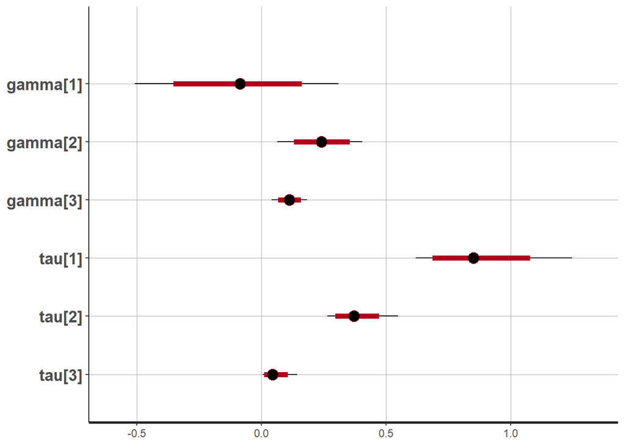

```r
plot(mod, pars = c('gamma','tau'))
```

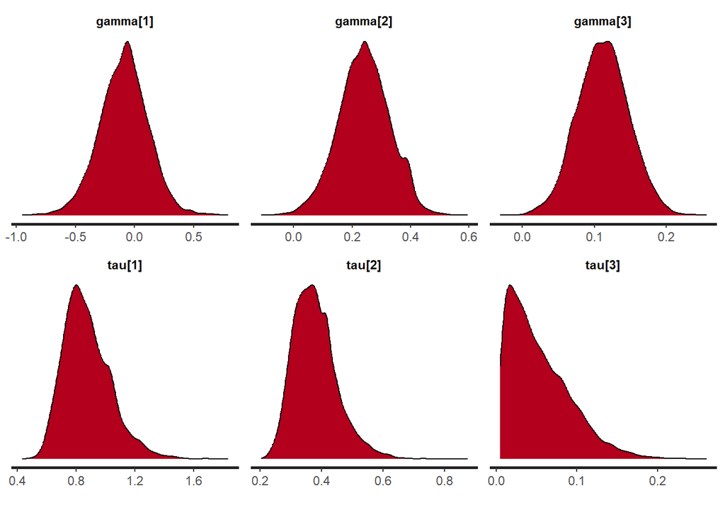

```r
stan_dens(mod, pars = c('gamma','tau'))
```

Congratulations! You are now able to fit a three-parameter DSEM on timeseries data including both fixed and random effects. Hopefully, you became a bit familiar with Stan blocks, data and variables types, and where to change and add declarations when expanding your model.

Do not hesitate to contact Michael or Jessica with further questions!